# Generate Figure 1 and Figure 2A

2023-06-22

## Setup

Let’s start by loading in our libraries, setting our working directory, and sourcing some functions

```r
library(ggplot2)
library(ggsignif)
library(graphics)
library(matlab)
library(DBI)
library(xtable)
library(egg)
library(AUCell)
library(xlsx)
library(growthrates)
library(purrr)
library(ggbreak)
library(dplyr)
library(tidyr)
setwd('~/Repositories/densityDependentSelection/code')
source('getGrowthModel.R')
source('utils.R')
```

## Get Cell Line r/K Parameters

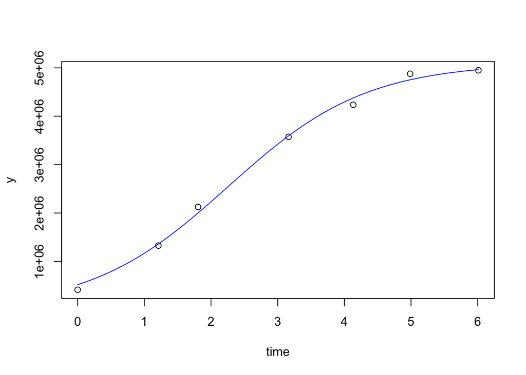

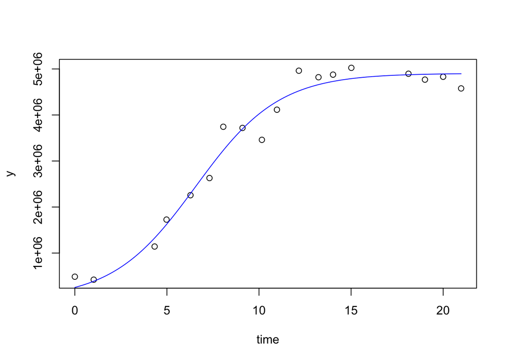

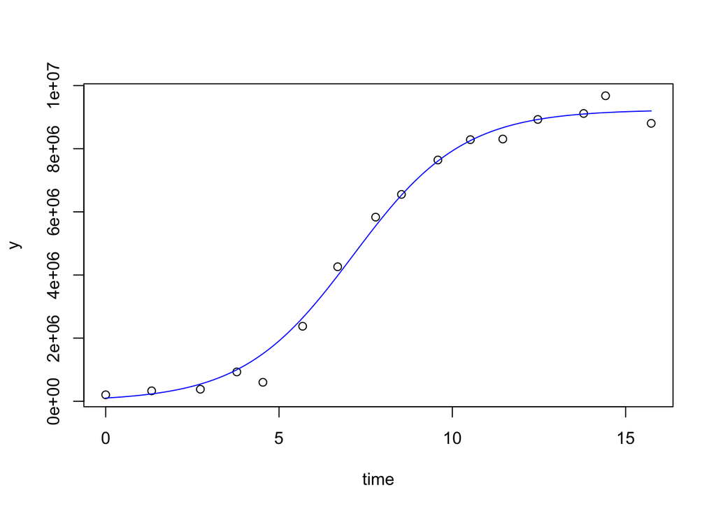

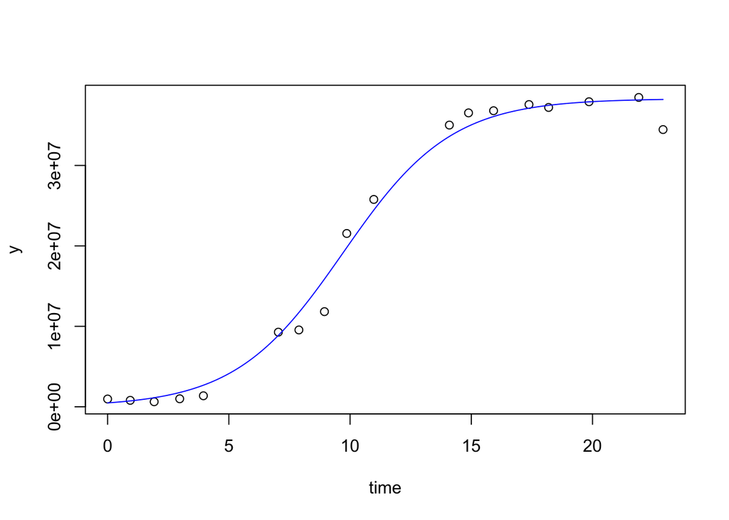

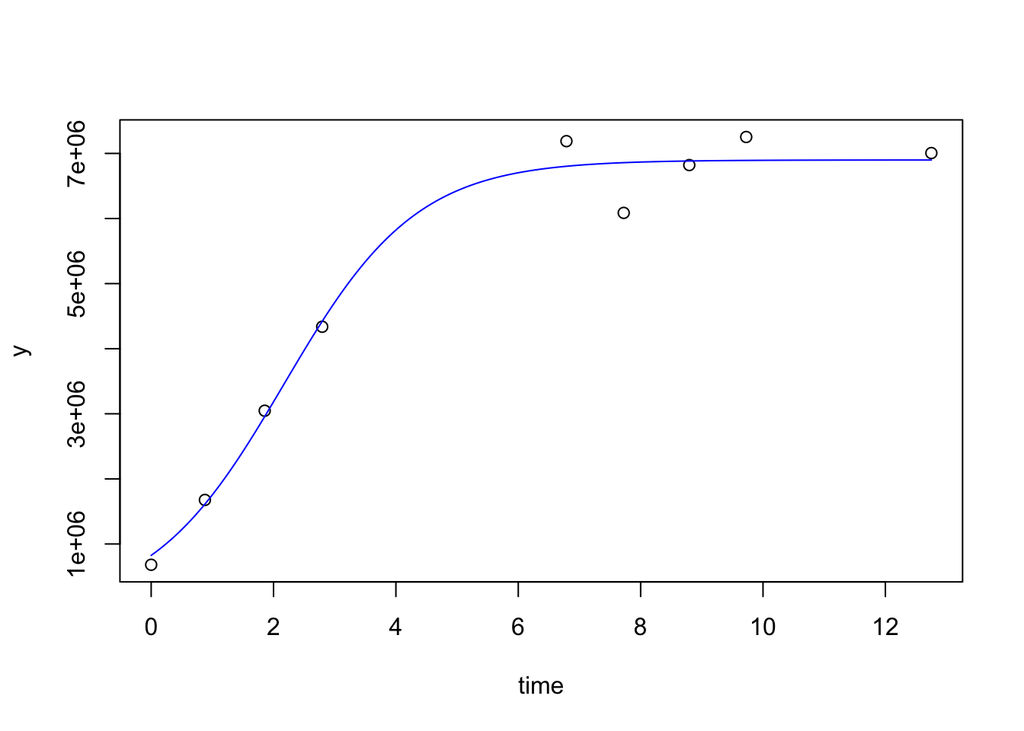

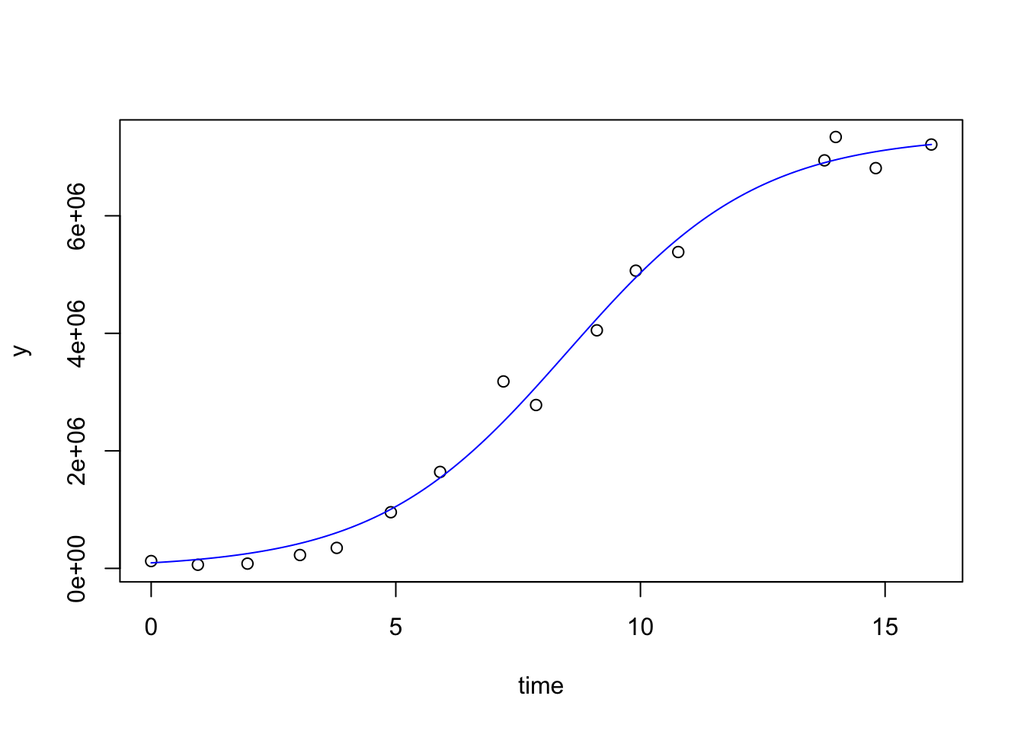

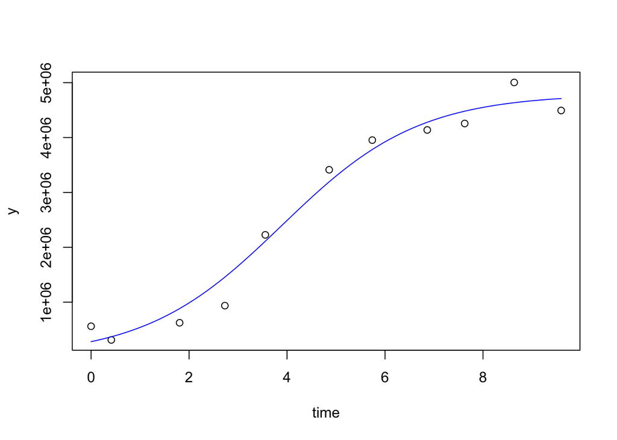

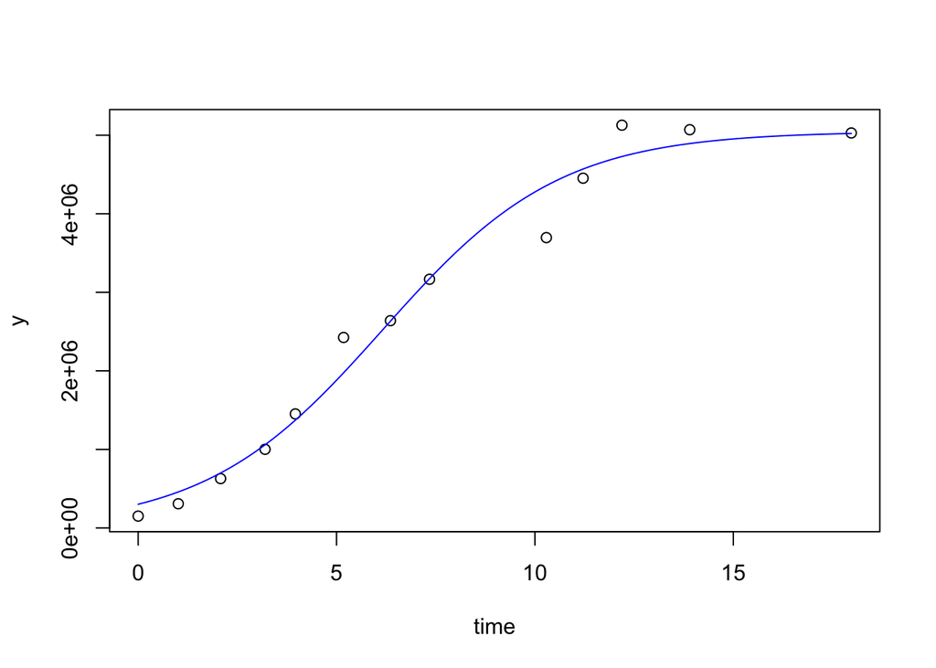

```r
lineages = sort(c("NUGC-4_A4_seed","NCI-N87_A59_seed","HGC-27_A22_seed","KATOIII_A6_seed","SNU-668_A9_seed" ,"MKN-45_A4_seed","SNU-638_A4_seed","SNU-601_A4_seed"));
cellLines = gsub("\\_.*","",lineages)
cellLinePairs = t(combn(unique(cellLines), 2))
modelTypes = list(Logistic = grow_logistic)
rSquares = matrix(NA, length(modelTypes), length(lineages), dimnames = list(names(modelTypes), lineages))
fits = list()
for (lineage in lineages) {
  tmp =try(getGrowthModel(lineage,modelTypes[["Logistic"]]))
  tmp$type = "Logistic"
  fits[[lineage]] = tmp
  targetDate = sort(as.POSIXct(tmp$out$date), decreasing=F)[round(nrow(tmp$out)*0.25)]
  rSquares["Logistic", lineage] = tmp$adjr2
}
```

```r
fitSummaryTable = data.frame(matrix(NA, nrow = length(lineages), ncol = 3, dimnames = list(lineages, c("r", "K", "adjutedRSquared"))))
fitSummaryTable$adjutedRSquared=sapply(lineages, function(x) round(max(rSquares[,x]), 4))
fitSummaryTable$r=sapply(lineages, function(x) round(fits[[x]]$modelsum@par["mumax"],2))
fitSummaryTable$K=sapply(lineages, function(x) round(fits[[x]]$modelsum@par["K"]))
fitSummaryTable$cellLine = gsub("\\_.*", "", rownames(fitSummaryTable))
rownames(fitSummaryTable) = fitSummaryTable$cellLine
fitSummaryTable[,1:3]
```

```
##            r        K adjutedRSquared
## HGC-27  0.96  5095550          0.9952
## KATOIII 0.44  4904316          0.9688
## MKN-45  0.63  9237232          0.9910
## NCI-N87 0.45 38306195          0.9877
## NUGC-4  0.92  6899073          0.9763
## SNU-601 0.51  7374909          0.9902
## SNU-638 0.71  4791667          0.9713
## SNU-668 0.45  5048178          0.9743
```

## Generate Figure 1A

Next, we gather up all the individual fits per cell line into one data frame and plot together. We also shift their curves along the x-axis such that the inflection point occurs at x=0 and plot in log-scale.

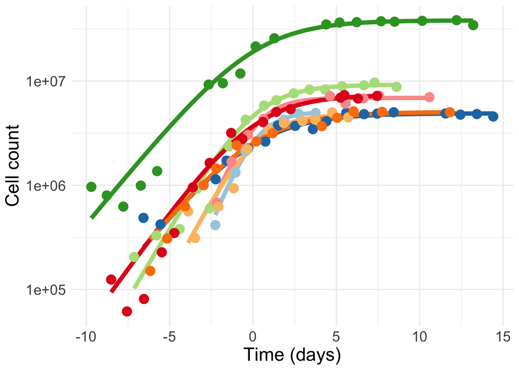

```r
# Find x-axis range need to accommodate all fits
maxDay = max(unlist(sapply(fits, function(x) x$modelsum@obs$time)))
x = seq(0, maxDay, by = 0.01)
# Extract our y-values from fits
ggplotGrowthCurves = lapply(fits, function(v) y = (v$modelsum@par["K"] * v$modelsum@par["y0"])/(v$modelsum@par["y0"] + (v$modelsum@par["K"] - v$modelsum@par["y0"]) * exp(-v$modelsum@par["mumax"] * x)))

# Shift plots along the x-axis so that they cross x=0 at their max growth rate
medians = sapply(ggplotGrowthCurves, function(x) median(0:max(na.omit(x))))
diffVals = sapply(names(fits), function(x) abs(ggplotGrowthCurves[[x]] - medians[[x]]))
daysToSubtract = apply(diffVals, 2, function(v) x[which.min(v)])

# Setup colors so that it is consistent across all plots
dd.col = RColorBrewer::brewer.pal(length(cellLines),"Paired");
names(dd.col) = cellLines

# Grab (x,y) coords for all cell line growth data and store in 'ggplotGrowthDataPoints'
ggplotGrowthDataPoints = list()
for (name in names(fits)){
  ggplotGrowthDataPoints[[name]] = fits[[name]]$modelsum@obs$time-daysToSubtract[[name]]
}
ggplotGrowthDataPoints = round(as.data.frame(unlist(ggplotGrowthDataPoints)),2)
names(ggplotGrowthDataPoints) = "xPoints"
ggplotGrowthDataPoints$yPoints = unlist(lapply(names(fits), function(x) fits[[x]]$modelsum@obs$y))
ggplotGrowthDataPoints$CL = gsub("\\_.*","",rownames(ggplotGrowthDataPoints))

# Rename daysToSubtract to match cell lines and populate ggplotGrowthCurves with shifted x-values (ggplotGrowthCurves$newDays)
names(daysToSubtract) = gsub("\\_.*","",names(daysToSubtract))
ggplotGrowthCurves = as.data.frame(unlist(ggplotGrowthCurves))
names(ggplotGrowthCurves) = "y"
ggplotGrowthCurves$CL = gsub("\\_.*","",rownames(ggplotGrowthCurves))
ggplotGrowthCurves$x = repmat(x,1)
ggplotGrowthCurves$newDays=unlist(lapply(unique(ggplotGrowthCurves$CL), function(z) ggplotGrowthCurves[ggplotGrowthCurves$CL==z, "x"]-daysToSubtract[z]))

# here we adjust the ggplotGrowthCurves so that each curve will end at the last data point for that cell line
# above when we find the ggplotGrowthCurves they are all solved over same timespan - this loop gives them all unique x-axes
adjuster = list()
for(CL in cellLines){
  cutOff = max(ggplotGrowthDataPoints[ggplotGrowthDataPoints$CL==CL, "xPoints"])
  tmp = ggplotGrowthCurves[ggplotGrowthCurves$newDays<=cutOff, ]
  tmp = tmp[tmp$CL==CL,]
  adjuster[[CL]] = tmp
}

ggplotGrowthCurves = adjuster %>% map_df(~rbind(.x), .id = 'CL')

# Create data frame to pass through to ggplot that contains ggplotGrowthCurves and ggplotGrowthDataPoints
dfT = list(df1 = ggplotGrowthCurves, df2 = ggplotGrowthDataPoints) %>%
  map_df(~rbind(.x), .id = 'df')

ggplot(data=dfT, aes(x=newDays, y=y, color=CL)) +
  geom_line(linewidth=2) + geom_point(aes(x=xPoints, y=yPoints), size=4) + scale_color_manual(values=dd.col) +
  scale_y_log10() + xlab("Time (days)") + ylab("Cell count") + theme_minimal() +
  theme(axis.text = element_text(size = 14), axis.title = element_text(size = 18), legend.position="none")
```

## Generate Figures 1C-D,1F-G

Here we go through KEGG pathways identified as differentially expressed between r-selected and K-selected HeLa cells and see which are the best biomarkers for these parameters in our cell lines. This section requires a combined AUCell object (ie, one object for all cell line scRNA-seq data analyzed together) per cell cycle state (G0/G1, S, G2M, all) input to be stored in data/auCellObjects. We also print the predicted r/K params for each subpopulation per cell line in this section.

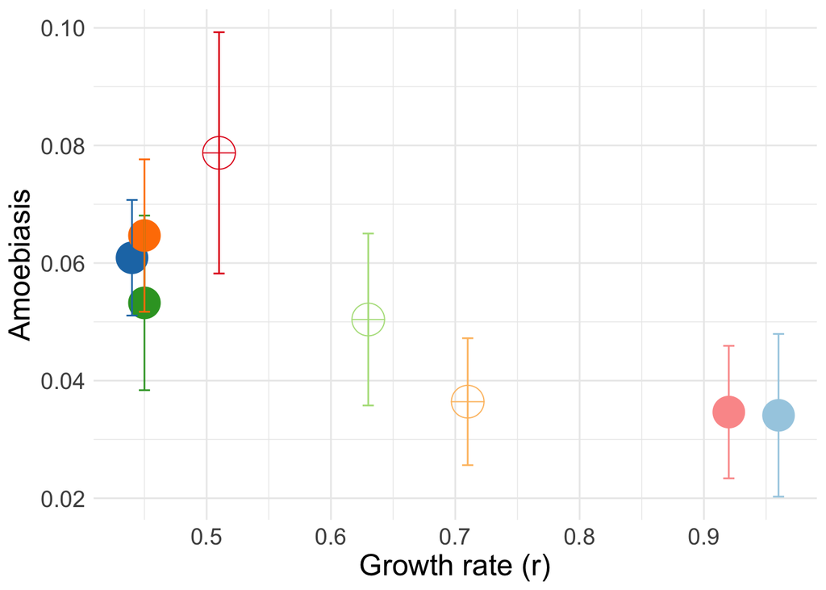

```r
# Set up list containing a pathway per r/K parameter
inputList = list("K"= "Arginine and proline metabolism", "r" = "Amoebiasis")
axesTitleList = list("K"= "Carrying capacity (K)", "r" = "Growth rate (r)")

# Compare pathways from hela paper to growth parameters:
poi=read.xlsx("../data/pathways/TableS2andS3_HelaPaper.xlsx",sheetName =  "LowDensity")
subpopGrowthParams = list()
pairs = teList = cellCycleClones = list()
maxPval=0.1
mapSigLevel = c("***"=0.001, "**"=0.01, "*"=0.05, "o"=0.1)
for(param in names(inputList)){
  teList_ = list()
  for(state in c("S","G0G1","G2M", "all")){
    # load CC specific AUCell object:
    load(file=paste0("../data/auCellObjects/uList_",state,".RObj"))
    teList_[[state]]=getStats4ParamFit(param,uList,poi, verbose=F)$te
    if(state=="G0G1"){
      cloneMembershipBarplot = as.data.frame(plyr::count(paste(uList$cloneMembership, uList$clMembership)))
      cloneMembershipBarplot = cloneMembershipBarplot %>% separate(x, c('clone', 'cellLine'), sep = " ")
      rownames(cloneMembershipBarplot) = cloneMembershipBarplot$clone
      cloneMembershipBarplot$ratio=sapply(cloneMembershipBarplot$clone, function(x) cloneMembershipBarplot[cloneMembershipBarplot$clone==x, "freq"]/sum(cloneMembershipBarplot[cloneMembershipBarplot$cellLine==cloneMembershipBarplot[cloneMembershipBarplot$clone==x,"cellLine"],"freq"]))
    }
  }
  teList[[param]]=do.call(rbind,teList_)
  # Choose cell cycle state with best model performance for this param:
  teList_=sapply(teList_, function(x) x[1,])
  state=colnames(teList_)[which.max(teList_[1,])]
  load(file=paste0("../data/auCellObjects/uList_",state,".RObj"))
  out =getStats4ParamFit(param,uList,poi)
  model = out$model

  # Build mapping of clones to cell lines
  clonesToCellLinesMap = as.data.frame(plyr::count(paste(uList$cloneMembership, uList$clMembership)))
  clonesToCellLinesMap = clonesToCellLinesMap %>% separate(x, c('clone', 'cellLine'), sep = " ")
  rownames(clonesToCellLinesMap) = clonesToCellLinesMap$clone

  # model predictions
  scDat=data.frame(indepVar1 = uList$pathways[inputList[[param]],])
  predVar = predict(model, scDat)
  if(param == "K"){
    predVar = exp(predVar)
  }

  ## set up data frame to use in ggplot
  scDat$prediction = predVar
  scDat$clone = uList$cloneMembership
  subpopGrowthParams[[param]] = as.data.frame(grpstats(as.matrix(scDat$prediction), as.matrix(scDat$clone), "median"))
  scDat$cellLine = uList$clMembership

  # get plot order for clones
  scDat = getPathwayActivityRanksAcrossCellLines(scDat)
  compsList = getLargestSignificantPair(scDat, clonesToCellLinesMap,cellLinePairs,maxOnly = T, maxPval = maxPval)
  list2env(compsList, .GlobalEnv)
  remove(compsList)

  # set step increase for plotting
  sI = 0.08
  mT = 0.005
  if(param=="K"){
    sI = 1.4
    mT = 0.90
  }

  g2 = ggplot(scDat, aes(x = reorder(clone, PL_rank), y = prediction,fill = cellLine)) +
    scale_fill_manual("Legend", values = dd.col) +
    geom_violin() +
    geom_signif(data=scDat,comparisons = subpopComps$clones, map_signif_level = mapSigLevel,step_increase=sI, test = "t.test",margin_top = mT) +    stat_summary(fun = median,geom = "point",size = 2,color = "black") +
    ylab(axesTitleList[param]) + xlab(NULL) +
    theme_minimal() +
    theme(axis.text.x = element_text(angle = 90, vjust = 0.5, hjust=1,size = 14),axis.text.y = element_text(size = 12), legend.position = "none", axis.title = element_text(size = 18))

  if(param=="K"){
    g3 = g2 + coord_trans( y = "log10");
  }

  # produce parameter over biomarker plot
  fitSummaryTable$biomarkerActivity = as.data.frame(grpstats(as.matrix(uList$pathways[inputList[[param]],]), uList$clMembership, "median"))[rownames(fitSummaryTable),]
  fitSummaryTable$parameterValue = fitSummaryTable[,param]
  fitSummaryTable$mad = sapply(fitSummaryTable$cellLine, function(x) mad(scDat[scDat$cellLine==x, "indepVar1"]))
  gg1 = ggplot(fitSummaryTable, aes(x=parameterValue, y=biomarkerActivity, group = cellLine, color = cellLine)) +
    scale_color_manual("Legend", values = dd.col) +
    geom_line() +
    geom_point(size=9, shape=c(16,16,10,16,16,10,10,16)) +
    geom_errorbar(aes(ymin=biomarkerActivity-mad, ymax=biomarkerActivity+mad)) +
    xlab(axesTitleList[param]) + ylab(inputList[[param]]) + theme_minimal() + theme(axis.title = element_text(size = 18), axis.text = element_text(size = 14), legend.position = "none")
  if(param=="K"){
    gg2 = gg1 + scale_x_log10()
  }

  # gather pairs of clones with significant difference
  compsList = getLargestSignificantPair(scDat, clonesToCellLinesMap,cellLinePairs,maxPval=0.1,maxOnly = F)
  pairs[[param]]=compsList$subpopComps
  colnames(pairs[[param]])=paste0(param,"_",colnames(pairs[[param]]))
}

print(gg1)
```

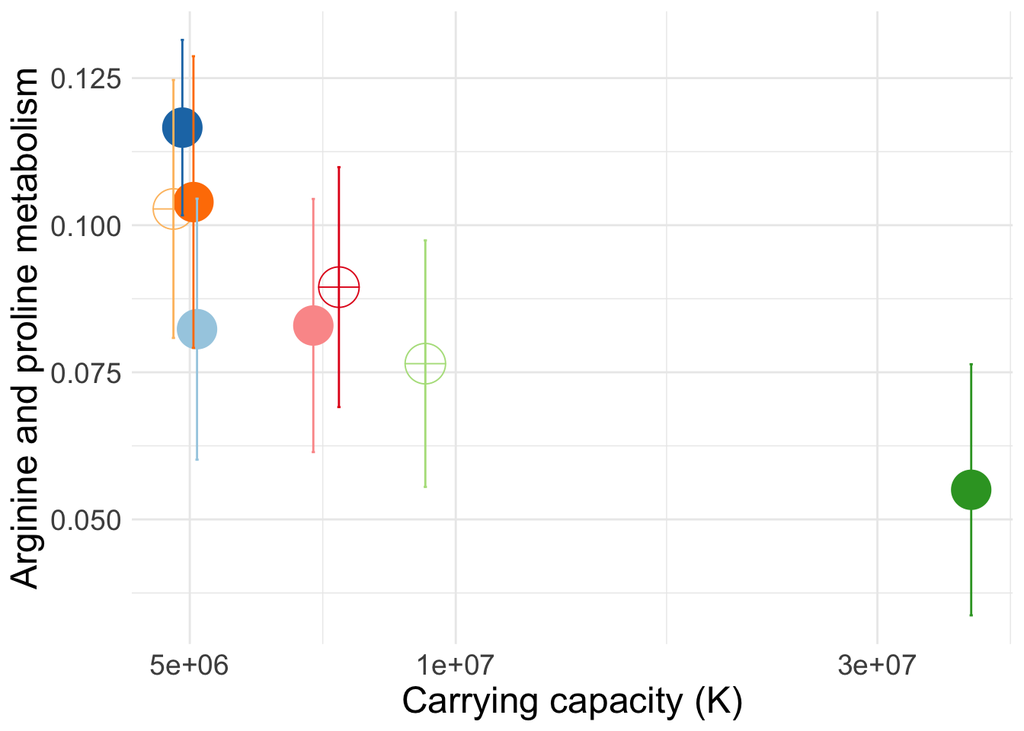

```r
print(gg2)
```

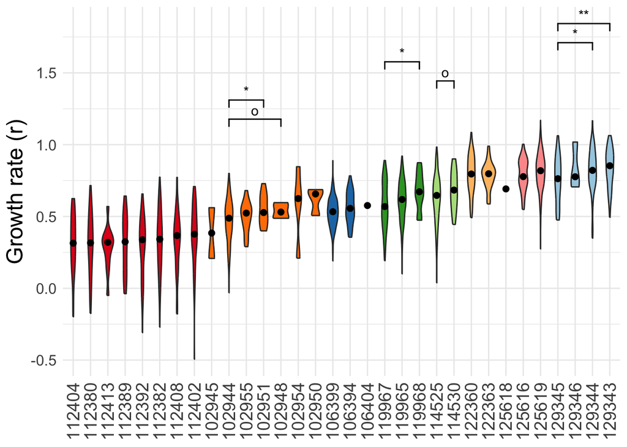

```r
print(g2)
```

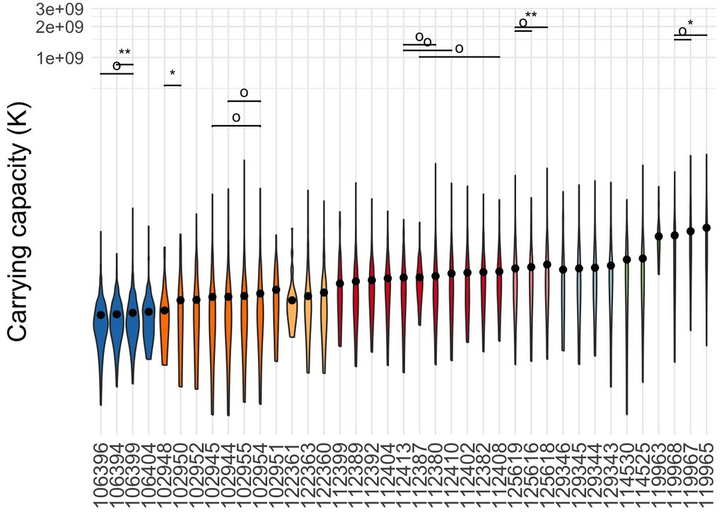

```r
print(g3)
```

```r
## check out subpop growth params
cloneCounts = plyr::count(unlist(sapply(subpopGrowthParams, function(x) rownames(x), simplify = F)))
clones= cloneCounts$x
subpopGrowthParams = base::cbind(subpopGrowthParams$K[clones,,drop=F], subpopGrowthParams$r[clones,,drop=F])
colnames(subpopGrowthParams) = c("K", "r")
subpopGrowthParams$CL = clonesToCellLinesMap[rownames(subpopGrowthParams), "cellLine"]
print(subpopGrowthParams)
```

```
##               K         r      CL
## 102944  4690105 0.4879531 SNU-668
## 102945  4674250 0.3845466 SNU-668
## 102948  3450777 0.5306050 SNU-668
## 102950  4331258 0.6565970 SNU-668
## 102951  5488042 0.5271468 SNU-668
## 102952  4379298        NA    <NA>
## 102954  5046408 0.6247041 SNU-668
## 102955  4773230 0.5233896 SNU-668
## 106394  3166668 0.5561791 KATOIII
## 106396  3117464        NA    <NA>
## 106399  3274342 0.5331240 KATOIII
## 106404  3346503 0.5762456 KATOIII
## 112380  7448892 0.3163632 SNU-601
## 112382  8148176 0.3414250 SNU-601
```

[output cut: 25 more lines]

## Generate Figure 1B

Print the top KEGG pathway biomarker for r/K params across cell lines identified in previous section.

```r
## Validation set: fewer pathways but tested for all cell lines:
sT=sapply(teList, function(x) cbind(rownames(x),x), simplify = F)
pTable=do.call(cbind,sT)
## Indices for top K pathways
kI=order(pTable$K.p.value)[1:5];
kI=teList$K[pTable$`K.rownames(x)`[kI],]
## Indices for top r pathways
rI=order(pTable$r.p.value)[1:5];
rI=teList$r[pTable$`r.rownames(x)`[rI],]
## p-val adjust
rK_Validation=rbind(rI,kI)
rK_Validation$correctedPval=p.adjust(rK_Validation$p.value,method = "fdr")
print(rK_Validation[,c(1,3:4)])
```

```
##                                      adj.r.squared    pearson correctedPval
## G2M.Amoebiasis                           0.6132735 -0.8176308    0.02632997
## S.RNA degradation                        0.5277234  0.7714866    0.04158750
## G2M.RNA transport                        0.5005619  0.7562474    0.04169498
## all.RNA transport                        0.4722019  0.7400011    0.04169498
## all.RNA degradation                      0.4646454  0.7356117    0.04169498
## all.Arginine and proline metabolism      0.6628035 -0.7731410    0.02632997
## G2M.Arginine and proline metabolism      0.6606843 -0.7653605    0.02632997
## S.Arginine and proline metabolism        0.6571810 -0.7560565    0.02632997
## G0G1.Arginine and proline metabolism     0.6328069 -0.7663272    0.02632997
## S.PI3K-Akt signaling pathway             0.3866199 -0.7994674    0.05892975
```

## Generate Figure 1E

The required input to this section (‘cloneMembershipBarplot’) is gathered in the same section that generates Figures 1C-D, and is hard-coded to display cells in G0/G1 phase which passed QC. This can be changed to display other cell cycle states or all cells.

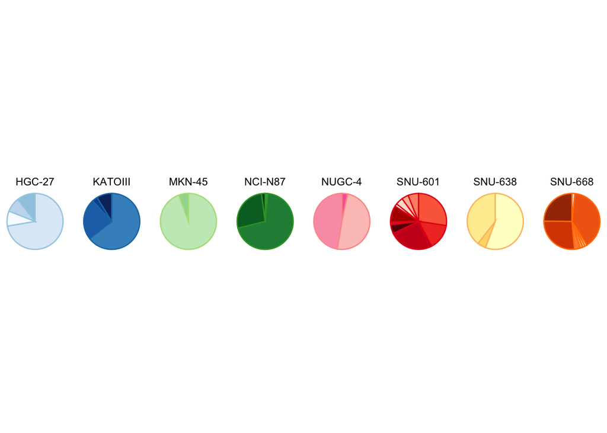

```r
## produce stacked bar plots for clonal membership
## number of clones may change depending on which cell cycle state you are looking at
new.dd.col=c("#FFF5EB","#F16913", "#FEE6CE", "#FDD0A2", "#FDAE6B" ,"#FD8D3C", "#D94801", "#A63603","#4292C6","#2171B5","#08519C", "#08306B", "#FB6A4A", "#EF3B2C", "#A50F15","#CB181D", "#67000D", "#D7301F", "#B30000","#FFF5F0", "#FEE0D2","#FCBBA1", "#FC9272","#C7E9C0", "#A1D99B","#41AB5D", "#238B45", "#006D2C", "#00441B", "#FFFFCC", "#FED976","#FFEDA0","#F768A1","#FCC5C0", "#FA9FB5","#DEEBF7","#F7FBFF", "#C6DBEF" ,"#9ECAE1")
names(new.dd.col) = cloneMembershipBarplot$clone
ggplot(data=cloneMembershipBarplot, aes(x=" ", y=ratio, group=cellLine, color=cellLine, fill=clone)) +
  scale_fill_manual("Legend", values = new.dd.col) +
  scale_color_manual("Legend", values = dd.col[unique(cloneMembershipBarplot$cellLine)]) +
  geom_bar(width = 1, stat = "identity") +
  coord_polar("y", start=0) +
  facet_grid(.~ cellLine) + theme_void() + theme(legend.position="none")
```

## Generate Figure 2A

The required input to this section (‘pairs’) is gathered in the same section that generates Figures 1C-D. It contains the pairs of clones within a cell line that contain significantly different r/K parameters (P<0.1).

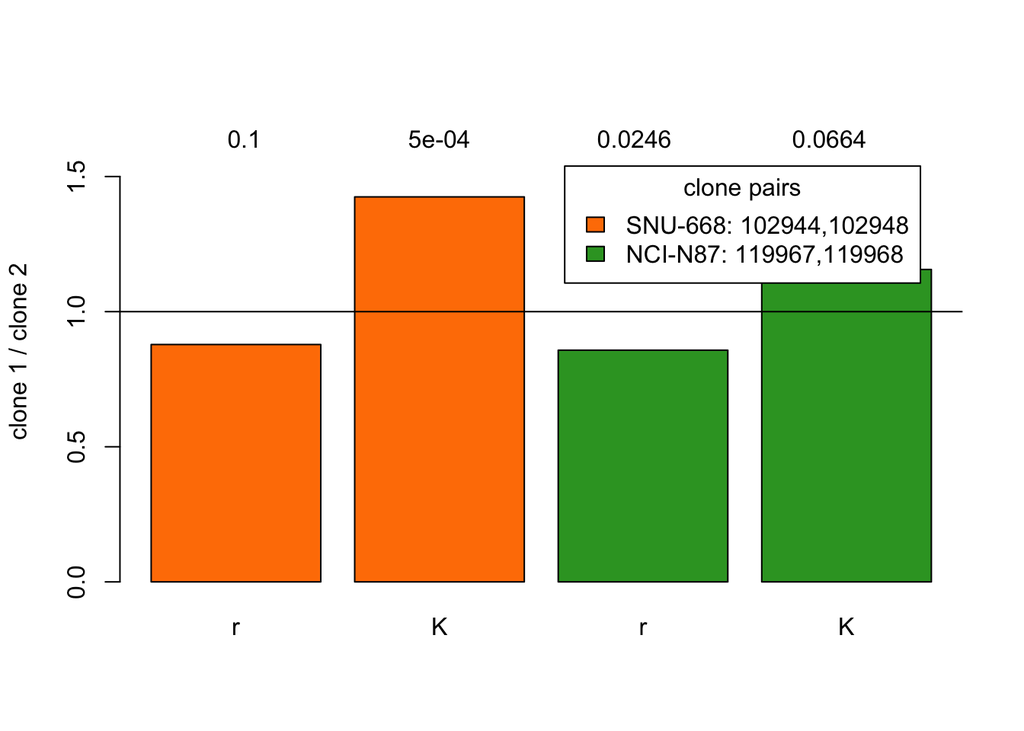

```r
## Find clone pairs with potential r/K trade-offs:
rK_pairs=cbind(pairs$r,pairs$K[rownames(pairs$r),])
rK_pairs=rK_pairs[!is.na(rK_pairs$r_src) & !is.na(rK_pairs$K_src),]
estimate=as.numeric(rbind(rK_pairs$r_estimate, rK_pairs$K_estimate))
pval=as.numeric(rbind(rK_pairs$r_pval, rK_pairs$K_pval))
## Plot them
col=sort(rep(dd.col[rK_pairs$r_src],2), decreasing = TRUE)
ymax=max(estimate)*1.2
barplot(estimate, col=col, names=rep(c("r","K"),nrow(rK_pairs)), ylab = "clone 1 / clone 2", ylim=c(0,ymax))
points(c(-1,100),c(1,1),type = "l")
leg=paste0(rK_pairs$r_src,": ", sapply(rK_pairs$r_clones, paste, collapse=","))
legend("topright", leg, fill=unique(col),title = "clone pairs",inset = c(0.05,0.1))
text(seq(0.75,length(pval)*1.15,1.15),rep(ymax*0.96,4),round(pval,4))
```